# TermProject_Part4

#### Jon Krenick Z23674518

#### Sydney Durrance Z23601407

```python
import pandas as pd
import numpy as np
import matplotlib.pyplot as plt
from mpl_toolkits.mplot3d import Axes3D
import seaborn as sns

from sklearn.preprocessing import OneHotEncoder
from sklearn.model_selection import train_test_split, KFold, cross_validate, cross_val_score
from sklearn.preprocessing import StandardScaler
from sklearn.decomposition import PCA
from sklearn.linear_model import LogisticRegression
from sklearn.cluster import KMeans
from sklearn.metrics import accuracy_score, precision_score, recall_score, f1_score, classification_report, confusion_matrix
```

```python
df = pd.read_csv('../Data/data_cleaned.csv')

df.head()
```

|  | Diabetes | HighBloodPressure | HighCholesterol | CholesterolCheck | BMI | Smoker | Stroke | HeartDiseaseOrAttack | PhysicalActivity | EatsFruitsDaily | ... | Education | Income | GeneralHealthGroup | MentalHealthDaysGroup | PhysicalHealthDaysGroup | BMIGroup | SexLabel | AgeGroup | EducationGroup | IncomeGroup |
| --- | --- | --- | --- | --- | --- | --- | --- | --- | --- | --- | --- | --- | --- | --- | --- | --- | --- | --- | --- | --- | --- |
| 0 | 0 | 1 | 1 | 1 | 40.0 | 1 | 0 | 0 | 0 | 0 | ... | 4 | 3 | Poor | Frequent Days | Frequent Days | Class 3 Obesity | Female | 60-64 | High School Graduate or GED | $15,000 to <$20,000 |
| 1 | 0 | 0 | 0 | 0 | 25.0 | 1 | 0 | 0 | 1 | 0 | ... | 6 | 1 | Good | No Days | No Days | Overweight | Female | 50-54 | College Graduate | Less than $10,000 |
| 2 | 0 | 1 | 1 | 1 | 28.0 | 0 | 0 | 0 | 0 | 1 | ... | 4 | 8 | Poor | Frequent Days | Frequent Days | Overweight | Female | 60-64 | High School Graduate or GED | $75,000+ |
| 3 | 0 | 1 | 0 | 1 | 27.0 | 0 | 0 | 0 | 1 | 1 | ... | 3 | 6 | Very Good | No Days | No Days | Overweight | Female | 70-74 | Completed Grades 9 through 11 | $35,000 to <$50,000 |
| 4 | 0 | 1 | 1 | 1 | 24.0 | 0 | 0 | 0 | 1 | 1 | ... | 5 | 4 | Very Good | Some Days | No Days | Healthy Weight | Female | 70-74 | Some College or Technical School | $20,000 to <$25,000 |

5 rows × 30 columns

```python
# Create a sub-dataset with the features used in Part 3
features = ['HighBloodPressure', 'HighCholesterol', 'BMI', 'HeartDiseaseOrAttack',
            'PhysicalActivity', 'GeneralHealth', 'Sex', 'AgeGroup']
X = df.loc[:, features]
y = df.loc[:, 'Diabetes']

encoder = OneHotEncoder(sparse_output = False, drop = None, handle_unknown =  'ignore')
encoder.set_output(transform = 'pandas')

agegroup_encoded = encoder.fit_transform(X[['AgeGroup']])

X_encoded = pd.concat([X.drop(columns = ['AgeGroup']), agegroup_encoded], axis = 1)
```

```python
# Standardize the features using StandardScaler
# src: https://scikit-learn.org/stable/modules/generated/sklearn.preprocessing.StandardScaler.html
scaler = StandardScaler()

X_scaled = scaler.fit_transform(X_encoded)

X_scaled
```

```
array([[ 1.09589157,  1.12440445,  1.66625089, ..., -0.32557652,
        -0.26801604, -0.28097773],
       [-0.91249904, -0.8893597 , -0.54314394, ..., -0.32557652,
        -0.26801604, -0.28097773],
       [ 1.09589157,  1.12440445, -0.10126497, ..., -0.32557652,
        -0.26801604, -0.28097773],
       ...,
       [-0.91249904, -0.8893597 , -0.10126497, ..., -0.32557652,
        -0.26801604, -0.28097773],
       [ 1.09589157, -0.8893597 , -0.83772991, ..., -0.32557652,
        -0.26801604, -0.28097773],
       [ 1.09589157,  1.12440445, -0.54314394, ..., -0.32557652,
        -0.26801604, -0.28097773]], shape=(229474, 20))
```

```python
# Fit PCA to standardized features
# src: https://scikit-learn.org/stable/modules/generated/sklearn.decomposition.PCA.html
pca = PCA(random_state = 42)

X_pca = pca.fit_transform(X_scaled)
```

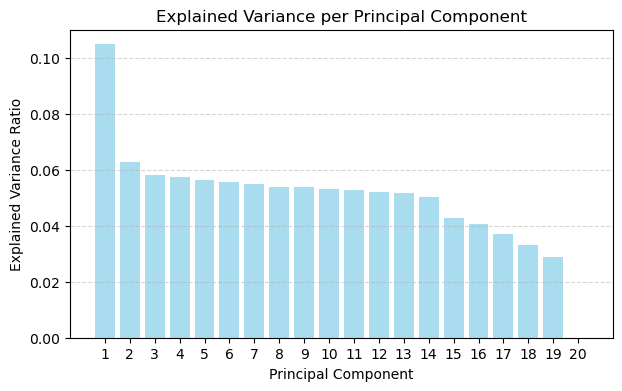

```python
# Plot the explained variance ratio for each component
explained_variance_ratio = pca.explained_variance_ratio_

plt.figure(figsize=(7, 4))
plt.bar(range(1, len(explained_variance_ratio) + 1), explained_variance_ratio, alpha=0.7, color='skyblue')
plt.xlabel('Principal Component')
plt.ylabel('Explained Variance Ratio')
plt.title('Explained Variance per Principal Component')
plt.xticks(range(1, len(explained_variance_ratio) + 1))
plt.grid(True, axis='y', linestyle='--', alpha=0.5)
plt.show()
```

```python
# Select enough components to explain at least 90% of the total variance
pd.DataFrame(data = explained_variance_ratio, columns = ['Variance']).assign(
    total_explained_variance = lambda x: x['Variance'].cumsum()
)
```

|  | Variance | total_explained_variance |
| --- | --- | --- |
| 0 | 0.104837 | 0.104837 |
| 1 | 0.062967 | 0.167804 |
| 2 | 0.058152 | 0.225956 |
| 3 | 0.057334 | 0.283290 |
| 4 | 0.056402 | 0.339692 |
| 5 | 0.055718 | 0.395410 |
| 6 | 0.054911 | 0.450321 |
| 7 | 0.053820 | 0.504141 |
| 8 | 0.053705 | 0.557846 |
| 9 | 0.052984 | 0.610830 |
| 10 | 0.052643 | 0.663474 |
| 11 | 0.052250 | 0.715724 |
| 12 | 0.051580 | 0.767303 |
| 13 | 0.050402 | 0.817705 |
| 14 | 0.042715 | 0.860421 |
| 15 | 0.040684 | 0.901105 |
| 16 | 0.036921 | 0.938026 |
| 17 | 0.033212 | 0.971238 |
| 18 | 0.028762 | 1.000000 |
| 19 | 0.000000 | 1.000000 |

```python
# Transform the standardized features using the selected number of components
pca = PCA(n_components = 16, random_state = 42)

X_pca_16 = pca.fit_transform(X_scaled)
```

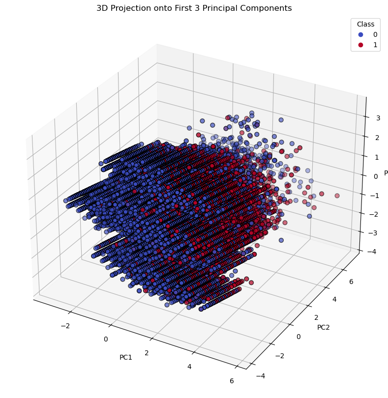

```python
# Visualize the first 3 principal components
fig = plt.figure(figsize=(15, 10))
ax = fig.add_subplot(111, projection='3d')

scatter = ax.scatter(
    X_pca_16[:, 0], X_pca_16[:, 1], X_pca_16[:, 2],
    c=y,  # or use cluster_labels
    cmap='coolwarm', edgecolor='k', s=40
)

ax.set_xlabel('PC1')
ax.set_ylabel('PC2')
ax.set_zlabel('PC3')
ax.set_title('3D Projection onto First 3 Principal Components')
plt.legend(*scatter.legend_elements(), title="Class")
plt.show()
```

```python
# Split the transformed dataset into training and testing splits
X_train, X_test, y_train, y_test = train_test_split(
    X_pca_16, y,
    test_size = 0.2, random_state = 42
)
```

```python
# Train Logistic Regression classifier using 5-fold cross-validation
k_fold = KFold(n_splits = 5)
log_reg = LogisticRegression()

log_reg_f1_scores = cross_validate(
    log_reg,
    X_train, y_train,
    cv = k_fold, scoring = ['accuracy', 'f1']
)

print(f"Average Accuracy across 5-folds: {log_reg_f1_scores['test_accuracy'].mean()}")
print(f"Average F1-Score across 5-folds: {log_reg_f1_scores['test_f1'].mean()}")
```

```
Average Accuracy across 5-folds: 0.8512520608437834
Average F1-Score across 5-folds: 0.21585514990103394
```

```python
# Fit and evaluate the model on the testing set and report F1 and accuracy
log_reg = LogisticRegression()
log_reg.fit(X_train, y_train)

y_pred = log_reg.predict(X_test)

log_reg_f1 = f1_score(y_test, y_pred)
log_reg_accuracy = accuracy_score(y_test, y_pred)

print(f"Logistic Regression Accuracy: {log_reg_accuracy}")
print(f"Logistic Regression F1-Score: {log_reg_f1}")
```

```
Logistic Regression Accuracy: 0.8498747140211352
Logistic Regression F1-Score: 0.2174011812812358
```

### **K-Means Clustering**

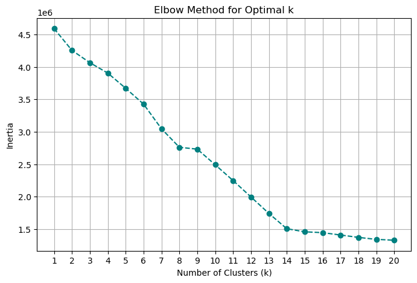

```python
# Perform k-means clustering on the standardized dataset and plot the inertia for k values 1-10
inertias = []
k_range = range(1, 21)

for k in k_range:
    kmeans = KMeans(n_clusters = k, random_state = 42)
    kmeans.fit(X_scaled)
    inertias.append(kmeans.inertia_)


plt.figure(figsize=(8, 5))
plt.plot(k_range, inertias, marker='o', linestyle='--', color='teal')
plt.title('Elbow Method for Optimal k')
plt.xlabel('Number of Clusters (k)')
plt.ylabel('Inertia')
plt.xticks(k_range)
plt.grid(True)
plt.show()
```

Using the elbow method, we can determine the sufficient number of clusters is 8

```python
# Fit k-means using the selected K
kmeans = KMeans(n_clusters = 8, random_state = 42)
cluster_labels = kmeans.fit_predict(X_scaled)
```

```python
# Get cluster centers in standardized feature space
cluster_centers = kmeans.cluster_centers_

# Convert to a DataFrame for readability
centers_df = pd.DataFrame(cluster_centers, columns=X_encoded.columns)
centers_df
```

|  | HighBloodPressure | HighCholesterol | BMI | HeartDiseaseOrAttack | PhysicalActivity | GeneralHealth | Sex | AgeGroup_18-24 | AgeGroup_25-29 | AgeGroup_30-34 | AgeGroup_35-39 | AgeGroup_40-44 | AgeGroup_45-49 | AgeGroup_50-54 | AgeGroup_55-59 | AgeGroup_60-64 | AgeGroup_65-69 | AgeGroup_70-74 | AgeGroup_75-79 | AgeGroup_80+ |
| --- | --- | --- | --- | --- | --- | --- | --- | --- | --- | --- | --- | --- | --- | --- | --- | --- | --- | --- | --- | --- |
| 0 | -0.497321 | -0.419388 | 0.051063 | -0.287631 | 0.099198 | -0.219732 | 0.008306 | -0.156865 | -0.178217 | -0.213713 | 4.214824 | -0.255286 | -0.285368 | -0.334733 | -0.367253 | -0.385411 | -0.381036 | -0.325577 | -0.268016 | -0.280978 |
| 1 | 0.342012 | 0.226768 | -0.119393 | 0.268459 | -0.077980 | 0.126707 | -0.036206 | -0.156865 | -0.178217 | -0.213713 | -0.237258 | -0.255286 | -0.285368 | -0.334733 | -0.367253 | -0.385411 | 1.046218 | -0.325577 | 0.735897 | 0.771486 |
| 2 | -0.266629 | -0.168810 | 0.124337 | -0.204307 | 0.027608 | -0.069960 | 0.021640 | -0.156865 | -0.178217 | -0.213713 | -0.237258 | -0.255286 | 3.504247 | -0.334733 | -0.367253 | -0.385411 | -0.381036 | -0.325577 | -0.268016 | -0.280978 |
| 3 | -0.547417 | -0.485486 | -0.031502 | -0.289265 | 0.159235 | -0.269170 | 0.045194 | 0.825626 | 0.938004 | 1.124829 | -0.237258 | 1.343640 | -0.285368 | -0.334733 | -0.367253 | -0.385411 | -0.381036 | -0.325577 | -0.268016 | -0.280978 |
| 4 | -0.122294 | -0.050182 | 0.106204 | -0.137147 | -0.013752 | 0.008339 | -0.002625 | -0.156865 | -0.178217 | -0.213713 | -0.237258 | -0.255286 | -0.285368 | 2.987460 | -0.367253 | -0.385411 | -0.381036 | -0.325577 | -0.268016 | -0.280978 |
| 5 | 0.016875 | 0.072554 | 0.095187 | -0.068926 | -0.029634 | 0.067697 | -0.011805 | -0.156865 | -0.178217 | -0.213713 | -0.237258 | -0.255286 | -0.285368 | -0.334733 | 2.722916 | -0.385411 | -0.381036 | -0.325577 | -0.268016 | -0.280978 |
| 6 | 0.143534 | 0.167327 | 0.062426 | 0.030904 | -0.026980 | 0.080624 | 0.021237 | -0.156865 | -0.178217 | -0.213713 | -0.237258 | -0.255286 | -0.285368 | -0.334733 | -0.367253 | 2.594634 | -0.381036 | -0.325577 | -0.268016 | -0.280978 |
| 7 | 0.359217 | 0.279911 | -0.054953 | 0.242482 | -0.037289 | 0.071096 | -0.007315 | -0.156865 | -0.178217 | -0.213713 | -0.237258 | -0.255286 | -0.285368 | -0.334733 | -0.367253 | -0.385411 | -0.381036 | 3.071475 | -0.268016 | -0.280978 |

### Cluster Centroid Analysis

Looking at the centroids, the eight clusters basically split the population by age group, and each one tells a pretty clear story about health. Cluster 3 groups the youngest respondents (18-34 plus 40-44) and is the healthiest of the bunch, with the lowest rates of high blood pressure (-0.55), high cholesterol (-0.49), and heart disease (-0.29), along with the highest physical activity. Clusters 0, 2, 4, 5, and 6 move through the 35-39, 45-49, 50-54, 55-59, and 60-64 age bands, and you can watch the health measures get steadily worse at each step. Clusters 7 (70-74) and 1 (65-69, 75-79, and 80+) are the oldest and have the worst chronic condition numbers, with high blood pressure at +0.36 and +0.34 and cholesterol at +0.28 and +0.23. The one measure that does not follow this pattern is BMI, which peaks in middle age (cluster 2 at +0.12) and then drops below average in the two oldest clusters, so the sickest groups are also the lightest. Sex stays within about +/-0.05 across all eight clusters, meaning it did not help separate anyone. Overall, the clusters describe a population that gets progressively less active and more likely to carry a chronic condition as it ages, with weight peaking in the middle years rather than at the end.